# Data disasters and how to avoid them

## Where we go wrong

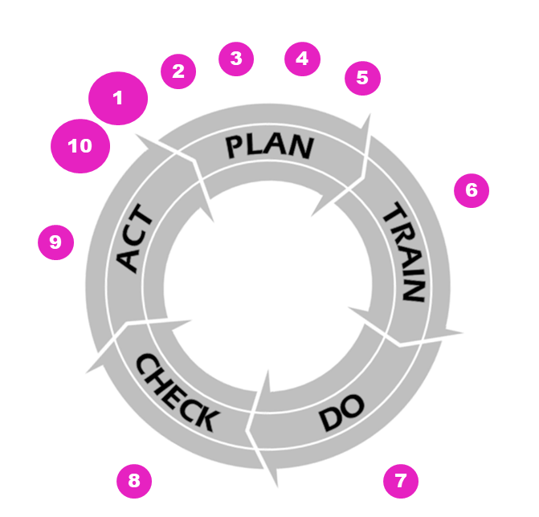

1. Identify & engage decision makers
2. Have a clear question
   - Who is going to do the analysis?
   - Ensure there is budget for it
3. Simulate & analyse some dummy data
   - Test & minimise survey questions (survey fatigue)
4. Decide on collection & safeguarding approach
5. Write up & record methods
6. Train staff (collection & analysis)
   - Keep the raw data (flexibility)

## Where we go wrong

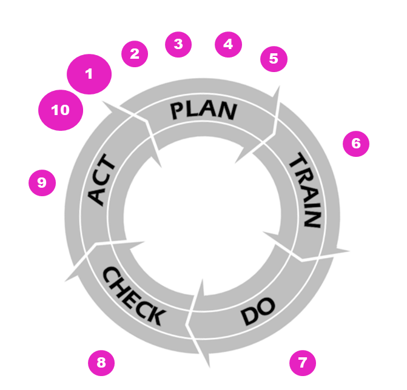

7. Ensure the data is collected in standardised way
- Record absences (zero is a number)
- Keep data tidy (machine readable)
8. Analyse & safeguard the data (have a data strategy)
- Exploit the pattern
9. Share your knowledge
   - Make it audience appropriate
10. Influence decision makers
    - Promote the evidence

## Automate data collection

**Advantages:**

- remove the hazards of data entry
- data automatically store in a tidy format
- data are safeguarded in a respository

**Examples:**

- Kobotoolbox [**www.kobotoolbox.org**](https://www.kobotoolbox.org/)
- Google forms [**www.google.com/forms/about**](https://www.google.com/forms/about/)
- SMART [**smartconservationtools.org**](https://smartconservationtools.org/)

[figure not shown]

## Use a tidy format

1. Every column is a variable (measurement)
2. Every row is a single observation
3. One value per cell

## Untidy

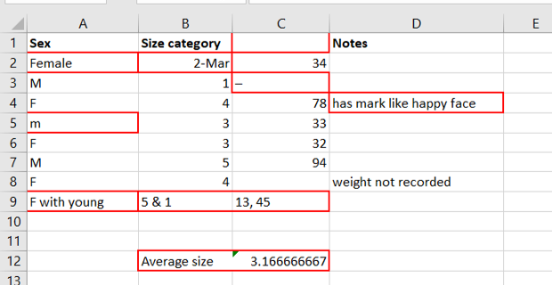

## Tidy

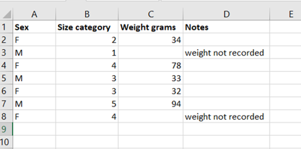

## Data strategy

A set of institutional guidelines, protocols, and systems to ensure that the knowledge gained from data is meaningful, safeguarded, accessible, shared and are used for decision making.

**Test:** If there is a risk of duplicating effort then you need a data strategy

**Critical to have Director buy in**

## Summary

- Good data integration beings and ends with decision makers
- Most data problems occur in the “Plan” phase
- Automation can solve data collection and safeguarding issues
- Organisations always have the same types of data issues
- All medium and large organisations should have a data strategy
- No organisational data strategy will work without director buy in